# Takeda EDA

# EDA OVERVIEW

## Questions of Interest

- How has per student consumption changed over time?
- Every year a new freshman class comes in - how has the consumption for incoming freshman classes changed? I think this can provide valuable insights for how desnat and other courses influence students. Similarly, can we break out each class year into their own 4 year “story” to see how they 3d printed more or less over time?
- Similarly, if you break down each years into freshman-senior earmarked consumption, which classes print the most each year? is it consistent (i.e. sophomores always win).
- Lastly, looking into how the class related consumptions have changed over the time they have been recorded
- Also, last but probably most important - if there is any data that you think other schools could provide that would be interesting to compare Olin’s metrics to, i.e. how much filament they buy or # of students with access, Daniela has contacts I need to reach out to with some Q’s

## Hypotheses to Explore

- Does first year desnat usage correlate with print usage following?
- How does print habits change over time within a given class?
- Percentage of total printing associated with a given class

## Questions from Data Analysis

- Source of population on campus numbers?
  - Is there a directory of students?
- How many students actually fill out the print log? How representative is this data?
  - Send student survey asking for estimates for how often students fill out the survey?

## Improvements to Data

- Ask students to use student ID number instead of name? Or use dropdown as current system is awful for data sorting

```r
getwd()
```

```
[1] "/Users/colintakeda/Code/olin/olin-3d-printing"
```

```r
load("data/df_both.Rdata")
```

[output not shown]

```r
load("data/df_graph.Rdata")
load("data/df_both_names.Rdata")
```

```r
df_both %>%
  glimpse()
```

```
Rows: 3,247
Columns: 13
$ timestamp        <dttm> 2021-11-29 19:37:03, 2021-11-29 19:37:24, 2021-11-29 21:37:33, 2021-11-29 22:32:55, 2021-11-29 22:33:49, 2021-11-29 22:39:01, 2021-11-30 02:23:45, 2021-11…
$ date             <date> 2021-11-29, 2021-11-29, 2021-11-29, 2021-11-29, 2021-11-29, 2021-11-29, 2021-11-30, 2021-11-30, 2021-11-30, 2021-11-30, 2021-11-30, 2021-11-30, 2021-11-30…
$ time             <times> 19:37:03, 19:37:24, 21:37:33, 22:32:55, 22:33:49, 22:39:01, 02:23:45, 02:38:07, 10:19:05, 10:41:50, 10:42:16, 10:44:53, 11:24:12, 11:31:44, 12:13:46, 12:…
$ name             <chr> "karen hinh", "karen hinh", "Chr Allum", "Sam Kaplan", "Avery Clowes", "sam kapaln", "alex", "Alex", "sam kaplan", "Audrey Abraham", "Audrey Abraham", "sam…
$ print_time       <chr> "8h30", "4h", "8ish hours", "2 hr 54", "8hrs 30 min", "3 hr 4", "6h7m", "17h20m", "1 hr 46", "15 hours", "44 minutes", "1hr 48", "8h53m", "2h21m", "10hr48m…
$ print_mass_grams <chr> "90", "40", "too damn much", "36g", "53g", "29 g", "45", "218", "13", "153", "1", "n/a", "97g", "27g", "121g", "2g", "4g", "21", "39g", "7g", "76", "60", "…
$ reason_print     <fct> Project Team/Club, Class Project/Research, Class Project/Research, Personal Project, Class Project/Research, Personal Project, Class Project/Research, Proj…
$ class            <fct> Proj. Team/Club, PIE, DFM, Personal Proj., PIE, Personal Proj., DFM, Proj. Team/Club, PIE, PIE, PIE, Personal Proj., PIE, PIE, Personal Proj., DFM, DFM, PI…
$ printer          <chr> NA, NA, NA, NA, NA, NA, NA, NA, NA, NA, NA, NA, NA, NA, NA, NA, NA, NA, NA, NA, NA, NA, NA, NA, NA, NA, NA, NA, NA, NA, NA, NA, NA, NA, NA, NA, NA, NA, NA,…
$ queue_pos        <dbl> NA, NA, NA, NA, NA, NA, NA, NA, NA, NA, NA, NA, NA, NA, NA, NA, NA, NA, NA, NA, NA, NA, NA, NA, NA, NA, NA, NA, NA, NA, NA, NA, NA, NA, NA, NA, NA, NA, NA,…
$ print_mass       <dbl> 90, 40, NA, 36, 53, 29, 45, 218, 13, 153, 1, NA, 97, 27, 121, 2, 4, 21, 39, 7, 76, 60, NA, NA, 131, 86, 17, 38, 101, 32, 122, 1, 20, 44, 9, 45, 41, 48, 2, …
$ num_on_campus    <dbl> 360, 360, 360, 360, 360, 360, 360, 360, 360, 360, 360, 360, 360, 360, 360, 360, 360, 360, 360, 360, 360, 360, 360, 360, 360, 360, 360, 360, 360, 360, 360, …
$ semester         <chr> "Fa21", "Fa21", "Fa21", "Fa21", "Fa21", "Fa21", "Fa21", "Fa21", "Fa21", "Fa21", "Fa21", "Fa21", "Fa21", "Fa21", "Fa21", "Fa21", "Fa21", "Fa21", "Fa21", "Fa…
```

```r
df_graph %>%
  glimpse()
```

```
Rows: 702,741
Columns: 6
Groups: date [1,461]
$ date            <date> 2019-01-01, 2019-01-02, 2019-01-03, 2019-01-04, 2019-01-05, 2019-01-06, 2019-01-07, 2019-01-08, 2019-01-09, 2019-01-10, 2019-01-11, 2019-01-12, 2019-01-13,…
$ mass_total      <dbl> NA, NA, NA, NA, NA, NA, NA, NA, NA, NA, NA, NA, NA, NA, NA, NA, NA, NA, NA, NA, NA, NA, NA, NA, NA, NA, NA, NA, NA, NA, NA, NA, NA, NA, NA, NA, NA, NA, NA, …
$ mass_normalized <dbl> 0, 0, 0, 0, 0, 0, 0, 0, 0, 0, 0, 0, 0, 0, 0, 0, 0, 0, 0, 0, 0, 0, 0, 0, 0, 0, 0, 0, 0, 0, 0, 0, 0, 0, 0, 0, 0, 0, 0, 0, 0, 0, 0, 0, 0, 0, 0, 0, 0, 0, 0, 0, …
$ num_normalized  <dbl> NA, NA, NA, NA, NA, NA, NA, NA, NA, NA, NA, NA, NA, NA, NA, NA, NA, NA, NA, NA, NA, NA, NA, NA, NA, NA, NA, NA, NA, NA, NA, NA, NA, NA, NA, NA, NA, NA, NA, …
$ semester        <chr> "Sp19", "Sp19", "Sp19", "Sp19", "Sp19", "Sp19", "Sp19", "Sp19", "Sp19", "Sp19", "Sp19", "Sp19", "Sp19", "Sp19", "Sp19", "Sp19", "Sp19", "Sp19", "Sp19", "Sp1…
$ num_on_campus   <dbl> 326, 326, 326, 326, 326, 326, 326, 326, 326, 326, 326, 326, 326, 326, 326, 326, 326, 326, 326, 326, 326, 326, 326, 326, 326, 326, 326, 326, 326, 326, 326, 3…
```

```r
df_both_names %>%
  glimpse()
```

```
Rows: 3,247
Columns: 14
$ timestamp        <dttm> 2021-11-29 19:37:03, 2021-11-29 19:37:24, 2021-11-29 21:37:33, 2021-11-29 22:32:55, 2021-11-29 22:33:49, 2021-11-29 22:39:01, 2021-11-30 02:23:45, 2021-11…
$ date             <date> 2021-11-29, 2021-11-29, 2021-11-29, 2021-11-29, 2021-11-29, 2021-11-29, 2021-11-30, 2021-11-30, 2021-11-30, 2021-11-30, 2021-11-30, 2021-11-30, 2021-11-30…
$ time             <times> 19:37:03, 19:37:24, 21:37:33, 22:32:55, 22:33:49, 22:39:01, 02:23:45, 02:38:07, 10:19:05, 10:41:50, 10:42:16, 10:44:53, 11:24:12, 11:31:44, 12:13:46, 12:…
$ name             <chr> "karen h", "karen h", "chris allum", "sam kaplan", "avery clowes", "sam kapaln", "alex", "alex", "sam kaplan", "audrey abraham", "audrey abraham", "sam kap…
$ print_time       <chr> "8h30", "4h", "8ish hours", "2 hr 54", "8hrs 30 min", "3 hr 4", "6h7m", "17h20m", "1 hr 46", "15 hours", "44 minutes", "1hr 48", "8h53m", "2h21m", "10hr48m…
$ print_mass_grams <chr> "90", "40", "too damn much", "36g", "53g", "29 g", "45", "218", "13", "153", "1", "n/a", "97g", "27g", "121g", "2g", "4g", "21", "39g", "7g", "76", "60", "…
$ reason_print     <fct> Project Team/Club, Class Project/Research, Class Project/Research, Personal Project, Class Project/Research, Personal Project, Class Project/Research, Proj…
$ class            <fct> Proj. Team/Club, PIE, DFM, Personal Proj., PIE, Personal Proj., DFM, Proj. Team/Club, PIE, PIE, PIE, Personal Proj., PIE, PIE, Personal Proj., DFM, DFM, PI…
$ printer          <chr> NA, NA, NA, NA, NA, NA, NA, NA, NA, NA, NA, NA, NA, NA, NA, NA, NA, NA, NA, NA, NA, NA, NA, NA, NA, NA, NA, NA, NA, NA, NA, NA, NA, NA, NA, NA, NA, NA, NA,…
$ queue_pos        <dbl> NA, NA, NA, NA, NA, NA, NA, NA, NA, NA, NA, NA, NA, NA, NA, NA, NA, NA, NA, NA, NA, NA, NA, NA, NA, NA, NA, NA, NA, NA, NA, NA, NA, NA, NA, NA, NA, NA, NA,…
$ print_mass       <dbl> 90, 40, NA, 36, 53, 29, 45, 218, 13, 153, 1, NA, 97, 27, 121, 2, 4, 21, 39, 7, 76, 60, NA, NA, 131, 86, 17, 38, 101, 32, 122, 1, 20, 44, 9, 45, 41, 48, 2, …
$ num_on_campus    <dbl> 360, 360, 360, 360, 360, 360, 360, 360, 360, 360, 360, 360, 360, 360, 360, 360, 360, 360, 360, 360, 360, 360, 360, 360, 360, 360, 360, 360, 360, 360, 360, …
$ semester         <chr> "Fa21", "Fa21", "Fa21", "Fa21", "Fa21", "Fa21", "Fa21", "Fa21", "Fa21", "Fa21", "Fa21", "Fa21", "Fa21", "Fa21", "Fa21", "Fa21", "Fa21", "Fa21", "Fa21", "Fa…
$ ame              <chr> "karen h", "karen h", "chris allum", "sam kaplan", "avery clowes", "sam kapaln", "alex", "alex", "sam kaplan", "audrey abraham", "audrey abraham", "sam kap…
```

```r
df_just_names <- df_both_names %>%
  select(name) %>%
  distinct(name)

write.csv(df_just_names, file = "data/df_just_names.csv")
```

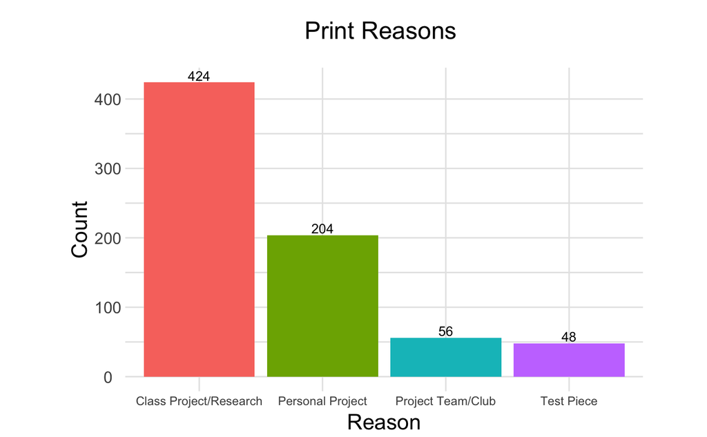

```r
df_both %>%
  count(reason_print) %>%
  filter(!is.na(reason_print)) %>%
  mutate(
    reason_print = reorder(reason_print, -n)
  ) %>%
  ggplot(aes(x = reason_print, y = n, fill = reason_print)) +
  geom_col(show.legend = FALSE) +
  theme_common() +
  # theme(axis.text.x = element_text(angle = 90, hjust = 1)) +
  theme(axis.text.x = element_text(size = 9)) +
  labs(
    title = "Print Reasons \n",
    x = "Reason",
    y = "Count"
  ) +
  geom_text(aes(label = n), size = 3.5, vjust = -.2, colour = "black")
```

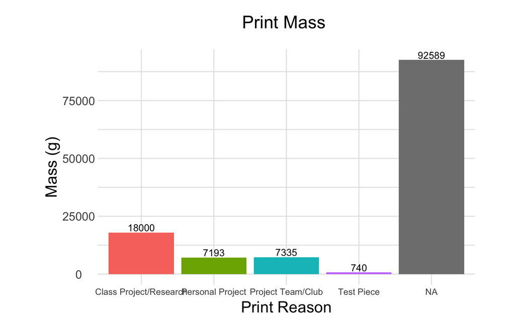

```r
#ggsave("figures/printReasonsWithLabels.jpg", dpi = 500, bg = "white")

df_both %>%
  group_by(reason_print) %>%
  #filter(!is.na(reason_print)) %>%
  summarize(
    print_mass = sum(print_mass, na.rm = TRUE)
  ) %>%
  ggplot(aes(x = reason_print, y = print_mass, fill = reason_print)) +
  geom_col(show.legend = FALSE) +
  theme_common() +
  # theme(axis.text.x = element_text(angle = 90, hjust = 1)) +
  theme(axis.text.x = element_text(size = 9)) +
  labs(
    title = "Print Mass \n",
    x = "Print Reason",
    y = "Mass (g)"
  ) +
  geom_text(aes(label = print_mass), size = 3.5, vjust = -.2, colour = "black")
```

```r
#ggsave("figures/printReasonsMassWithLabels.jpg", dpi = 500, bg = "white")
```

## Observations

- Unclear why NA is so high compared to all other sources
- Is this due to high volume users or due to individuals not reporting the print reason